# Assignment 4

Anne Chen

Github repo: https://github.com/chenac232/advML

Option #2:

Use a dataset of interest to you to build machine learning models and then compare predictions of at least three models on test data. A number of you have expressed interest and put in the time to gather (or find) your own data and to implement the modelling approaches we have studied to analyze this data. This assignment will give you the opportunity to write up what you have found in this process. Please be sure to describe your dataset (including the features, target, and the general type of data you are working with). Describe each model you will run. Then compare results.

Please save your jupyter notebook to an html file and upload it to this assignment to complete your final report.

# 0. Data

I'm interested in seeing whether I can predict bank holdings of agency MBS using some financial markets data related to underlying interest rates.

Below are data I will be using:

1. H8 bank holdings data of agency MBS (FRED) - this will be our target variable The rest are features that are known to have some relationship with bank holdings of MBS:
2. H8 bank loans (FRED)
3. H.4.1 Agency MBS holdings of SOMA portfolio (FRED)
4. Fed funds rate (FRED)
5. 5-year treasury yields (WSJ)
6. 10-year treasury yields (WSJ)

# 1. Set up

```python
import pandas as pd
import numpy as np
from functools import reduce
```

```python
import os
from google.colab import drive
drive.mount('/content/drive')
```

```python
h41 = pd.read_csv('/content/drive/My Drive/Adv ML/Assignment 4/h41_mbs.csv')
h41.head()
```

|  | DATE | WSHOMCB |
| --- | --- | --- |
| 0 | 2018-04-25 | 1744967.0 |
| 1 | 2018-05-02 | 1744972.0 |
| 2 | 2018-05-09 | 1744972.0 |
| 3 | 2018-05-16 | 1745514.0 |
| 4 | 2018-05-23 | 1744179.0 |

```python
holdings = pd.read_csv('/content/drive/My Drive/Adv ML/Assignment 4/h8_mbs.csv')
loans = pd.read_csv('/content/drive/My Drive/Adv ML/Assignment 4/h8_loans.csv')
fedfunds = pd.read_csv('/content/drive/My Drive/Adv ML/Assignment 4/FEDFUNDS.csv')
tsy10 = pd.read_csv('/content/drive/My Drive/Adv ML/Assignment 4/10yr_yields.csv')
tsy5 = pd.read_csv('/content/drive/My Drive/Adv ML/Assignment 4/5yr_yields.csv')
```

### check how the data looks and clean up a little

```python
h41cols = ['date', 'soma_mbs']
h41.columns = h41cols
```

```python
h41.date = pd.to_datetime(h41.date)
```

```python
cols10 = ['date', 'open10', 'high10', 'low10', 'close10']
tsy10.columns = cols10

cols5 = ['date', 'open5', 'high5', 'low5', 'close5']
tsy5.columns = cols5
```

```python
lcols = ['date', 'loans']
loans.columns = lcols

hcols = ['date', 'holdings']
holdings.columns = hcols

fcols = ['date', 'fedfunds']
fedfunds.columns = fcols
```

```python
tsy5.date = pd.to_datetime(tsy5.date)
tsy5.head()
```

|  | date | open5 | high5 | low5 | close5 |
| --- | --- | --- | --- | --- | --- |
| 0 | 2023-04-21 | 3.626 | 3.674 | 3.579 | 3.665 |
| 1 | 2023-04-20 | 3.708 | 3.735 | 3.618 | 3.626 |
| 2 | 2023-04-19 | 3.684 | 3.759 | 3.680 | 3.708 |
| 3 | 2023-04-18 | 3.708 | 3.710 | 3.654 | 3.684 |
| 4 | 2023-04-17 | 3.611 | 3.713 | 3.597 | 3.708 |

```python
tsy10.date = pd.to_datetime(tsy10.date)
tsy10.head()
```

|  | date | open10 | high10 | low10 | close10 |
| --- | --- | --- | --- | --- | --- |
| 0 | 2023-04-21 | 3.538 | 3.579 | 3.507 | 3.577 |
| 1 | 2023-04-20 | 3.594 | 3.613 | 3.528 | 3.538 |
| 2 | 2023-04-19 | 3.578 | 3.639 | 3.578 | 3.594 |
| 3 | 2023-04-18 | 3.606 | 3.607 | 3.558 | 3.578 |
| 4 | 2023-04-17 | 3.519 | 3.607 | 3.507 | 3.606 |

```python
holdings.date = pd.to_datetime(holdings.date)
holdings.head()
```

|  | date | holdings |
| --- | --- | --- |
| 0 | 2009-07-01 | 993.3510 |
| 1 | 2009-07-08 | 991.7135 |
| 2 | 2009-07-15 | 975.9511 |
| 3 | 2009-07-22 | 968.2832 |
| 4 | 2009-07-29 | 965.3428 |

```python
loans.date = pd.to_datetime(loans.date)
loans = loans.sort_values(by='date', ascending=False)
loans.head()
```

|  | date | loans |
| --- | --- | --- |
| 260 | 2023-04-12 | 12089.3380 |
| 259 | 2023-04-05 | 12075.5121 |
| 258 | 2023-03-29 | 12065.3096 |
| 257 | 2023-03-22 | 12110.3794 |
| 256 | 2023-03-15 | 12169.8703 |

```python
fedfunds.date = pd.to_datetime(fedfunds.date)
fedfunds.head()
```

|  | date | fedfunds |
| --- | --- | --- |
| 0 | 2018-03-01 | 1.51 |
| 1 | 2018-04-01 | 1.69 |
| 2 | 2018-05-01 | 1.70 |
| 3 | 2018-06-01 | 1.82 |
| 4 | 2018-07-01 | 1.91 |

### Merge everything and clean up some more

```python
dfs = [holdings, loans, fedfunds, tsy10, tsy5, h41]
df = reduce(lambda  left,right: pd.merge(left, right, on=['date'],
                                            how='outer'), dfs)
df.head()
```

|  | date | holdings | loans | fedfunds | open10 | high10 | low10 | close10 | open5 | high5 | low5 | close5 | soma_mbs |
| --- | --- | --- | --- | --- | --- | --- | --- | --- | --- | --- | --- | --- | --- |
| 0 | 2009-07-01 | 993.3510 | NaN | NaN | NaN | NaN | NaN | NaN | NaN | NaN | NaN | NaN | NaN |
| 1 | 2009-07-08 | 991.7135 | NaN | NaN | NaN | NaN | NaN | NaN | NaN | NaN | NaN | NaN | NaN |
| 2 | 2009-07-15 | 975.9511 | NaN | NaN | NaN | NaN | NaN | NaN | NaN | NaN | NaN | NaN | NaN |
| 3 | 2009-07-22 | 968.2832 | NaN | NaN | NaN | NaN | NaN | NaN | NaN | NaN | NaN | NaN | NaN |
| 4 | 2009-07-29 | 965.3428 | NaN | NaN | NaN | NaN | NaN | NaN | NaN | NaN | NaN | NaN | NaN |

```python
df.dtypes
```

```
date        datetime64[ns]
holdings           float64
loans              float64
fedfunds           float64
open10             float64
high10             float64
low10              float64
close10            float64
open5              float64
high5              float64
low5               float64
close5             float64
soma_mbs           float64
dtype: object
```

```python
df = df.sort_values(by='date', ascending=True)
df.head()
```

|  | date | holdings | loans | fedfunds | open10 | high10 | low10 | close10 | open5 | high5 | low5 | close5 | soma_mbs |
| --- | --- | --- | --- | --- | --- | --- | --- | --- | --- | --- | --- | --- | --- |
| 0 | 2009-07-01 | 993.3510 | NaN | NaN | NaN | NaN | NaN | NaN | NaN | NaN | NaN | NaN | NaN |
| 1 | 2009-07-08 | 991.7135 | NaN | NaN | NaN | NaN | NaN | NaN | NaN | NaN | NaN | NaN | NaN |
| 2 | 2009-07-15 | 975.9511 | NaN | NaN | NaN | NaN | NaN | NaN | NaN | NaN | NaN | NaN | NaN |
| 3 | 2009-07-22 | 968.2832 | NaN | NaN | NaN | NaN | NaN | NaN | NaN | NaN | NaN | NaN | NaN |
| 4 | 2009-07-29 | 965.3428 | NaN | NaN | NaN | NaN | NaN | NaN | NaN | NaN | NaN | NaN | NaN |

```python
df = df.fillna(method='ffill')
```

```python
df = df.sort_values(by='date', ascending=False)
df.head()
```

|  | date | holdings | loans | fedfunds | open10 | high10 | low10 | close10 | open5 | high5 | low5 | close5 | soma_mbs |
| --- | --- | --- | --- | --- | --- | --- | --- | --- | --- | --- | --- | --- | --- |
| 771 | 2023-04-21 | 2600.421 | 12089.338 | 4.65 | 3.538 | 3.579 | 3.507 | 3.577 | 3.626 | 3.674 | 3.579 | 3.665 | 2593042.0 |
| 772 | 2023-04-20 | 2600.421 | 12089.338 | 4.65 | 3.594 | 3.613 | 3.528 | 3.538 | 3.708 | 3.735 | 3.618 | 3.626 | 2593042.0 |
| 773 | 2023-04-19 | 2600.421 | 12089.338 | 4.65 | 3.578 | 3.639 | 3.578 | 3.594 | 3.684 | 3.759 | 3.680 | 3.708 | 2593042.0 |
| 774 | 2023-04-18 | 2600.421 | 12089.338 | 4.65 | 3.606 | 3.607 | 3.558 | 3.578 | 3.708 | 3.710 | 3.654 | 3.684 | 2594480.0 |
| 775 | 2023-04-17 | 2600.421 | 12089.338 | 4.65 | 3.519 | 3.607 | 3.507 | 3.606 | 3.611 | 3.713 | 3.597 | 3.708 | 2594480.0 |

```python
# get weekly
df['dayweek'] = df.date.dt.dayofweek

# keep only friday, dayweek = 4
df = df.loc[df.dayweek == 4].copy()
df.head()
```

|  | date | holdings | loans | fedfunds | open10 | high10 | low10 | close10 | open5 | high5 | low5 | close5 | soma_mbs | dayweek |
| --- | --- | --- | --- | --- | --- | --- | --- | --- | --- | --- | --- | --- | --- | --- |
| 771 | 2023-04-21 | 2600.4210 | 12089.3380 | 4.65 | 3.538 | 3.579 | 3.507 | 3.577 | 3.626 | 3.674 | 3.579 | 3.665 | 2593042.0 | 4 |
| 776 | 2023-04-14 | 2600.4210 | 12089.3380 | 4.65 | 3.446 | 3.539 | 3.424 | 3.519 | 3.498 | 3.635 | 3.467 | 3.611 | 2594480.0 | 4 |
| 780 | 2023-04-07 | 2610.3038 | 12075.5121 | 4.65 | 3.307 | 3.406 | 3.279 | 3.405 | 3.379 | 3.509 | 3.323 | 3.506 | 2594480.0 | 4 |
| 784 | 2023-03-31 | 2585.0138 | 12065.3096 | 4.65 | 3.553 | 3.590 | 3.471 | 3.471 | 3.684 | 3.718 | 3.577 | 3.580 | 2594480.0 | 4 |
| 788 | 2023-03-24 | 2691.8772 | 12110.3794 | 4.65 | 3.422 | 3.426 | 3.289 | 3.376 | 3.448 | 3.448 | 3.237 | 3.414 | 2605235.0 | 4 |

```python
# we want to look at the weekly change in holdings, so let's calculate that
df['change'] = df.holdings.diff(periods=1)
```

```python
df = df.dropna()
```

```python
df.head()
```

|  | date | holdings | loans | fedfunds | open10 | high10 | low10 | close10 | open5 | high5 | low5 | close5 | soma_mbs | dayweek | change |
| --- | --- | --- | --- | --- | --- | --- | --- | --- | --- | --- | --- | --- | --- | --- | --- |
| 776 | 2023-04-14 | 2600.4210 | 12089.3380 | 4.65 | 3.446 | 3.539 | 3.424 | 3.519 | 3.498 | 3.635 | 3.467 | 3.611 | 2594480.0 | 4 | 0.0000 |
| 780 | 2023-04-07 | 2610.3038 | 12075.5121 | 4.65 | 3.307 | 3.406 | 3.279 | 3.405 | 3.379 | 3.509 | 3.323 | 3.506 | 2594480.0 | 4 | 9.8828 |
| 784 | 2023-03-31 | 2585.0138 | 12065.3096 | 4.65 | 3.553 | 3.590 | 3.471 | 3.471 | 3.684 | 3.718 | 3.577 | 3.580 | 2594480.0 | 4 | -25.2900 |
| 788 | 2023-03-24 | 2691.8772 | 12110.3794 | 4.65 | 3.422 | 3.426 | 3.289 | 3.376 | 3.448 | 3.448 | 3.237 | 3.414 | 2605235.0 | 4 | 106.8634 |
| 792 | 2023-03-17 | 2727.2932 | 12169.8703 | 4.65 | 3.584 | 3.595 | 3.377 | 3.430 | 3.733 | 3.778 | 3.454 | 3.510 | 2608741.0 | 4 | 35.4160 |

# 2. Summary Stats and Charting

Let's take a look at the data and see whether we can spot any relationships between the target variable and feature data.

```python
df.describe()
```

|  | holdings | loans | fedfunds | open10 | high10 | low10 | close10 | open5 | high5 | low5 | close5 | soma_mbs | dayweek | change |
| --- | --- | --- | --- | --- | --- | --- | --- | --- | --- | --- | --- | --- | --- | --- |
| count | 254.000000 | 254.000000 | 254.000000 | 254.000000 | 254.000000 | 254.000000 | 254.000000 | 254.000000 | 254.000000 | 254.000000 | 254.000000 | 2.540000e+02 | 254.0 | 254.000000 |
| mean | 2409.234467 | 10451.335680 | 1.412165 | 2.119787 | 2.158154 | 2.079984 | 2.118567 | 1.895894 | 1.935504 | 1.853677 | 1.894976 | 2.063736e+06 | 4.0 | -3.170931 |
| std | 419.868983 | 785.236024 | 1.340158 | 0.959226 | 0.968022 | 0.957511 | 0.964382 | 1.166383 | 1.182227 | 1.157549 | 1.171523 | 4.777396e+05 | 0.0 | 13.818989 |
| min | 1792.106800 | 9276.235400 | 0.050000 | 0.540000 | 0.560000 | 0.518000 | 0.535000 | 0.215000 | 0.233000 | 0.200000 | 0.211000 | 1.366676e+06 | 4.0 | -54.592400 |
| 25% | 2003.609275 | 9820.801800 | 0.090000 | 1.449000 | 1.472250 | 1.413250 | 1.437250 | 0.819500 | 0.839000 | 0.787750 | 0.811000 | 1.622089e+06 | 4.0 | -9.256650 |
| 50% | 2390.647350 | 10374.247150 | 1.550000 | 1.906500 | 1.947500 | 1.881000 | 1.915500 | 1.732000 | 1.772000 | 1.686000 | 1.750000 | 2.001980e+06 | 4.0 | -2.992900 |
| 75% | 2824.173725 | 10818.897025 | 2.330000 | 2.911750 | 2.947500 | 2.871750 | 2.918750 | 2.826750 | 2.853000 | 2.786250 | 2.815250 | 2.609480e+06 | 4.0 | 2.653175 |
| max | 3002.874000 | 12169.870300 | 4.650000 | 4.232000 | 4.325000 | 4.205000 | 4.228000 | 4.446000 | 4.504000 | 4.318000 | 4.350000 | 2.740185e+06 | 4.0 | 106.863400 |

```python
# charting
import seaborn as sns
import matplotlib.pyplot as plt
```

You can see in the chart below that bank holdings of agency MBS increased drastically over the pandemic furing a low federal funds rate environemnt

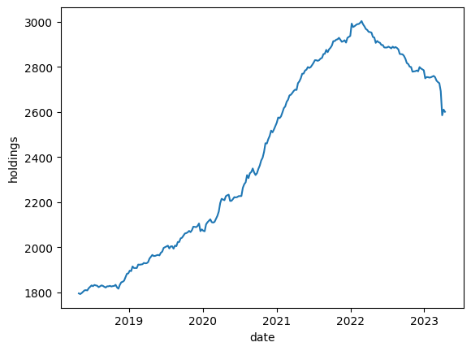

```python
sns.lineplot(data=df, x='date', y='holdings')
```

Meanwhile, loans at banks almost had an inverse relationship, increasing sharply beginning March 2020, dropping into 2021 until 2022.

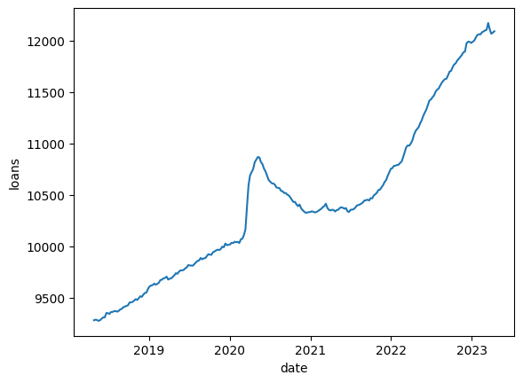

```python
sns.lineplot(data=df, x='date', y='loans')
```

Rates dropped drastically after March 2020, then increased drastically after 2022.

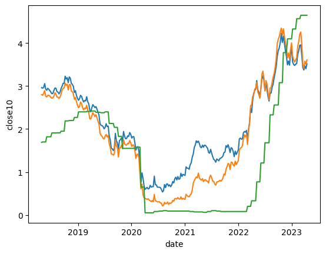

```python
sns.lineplot(data=df, x='date', y='close10')
sns.lineplot(data=df, x='date', y='close5')
sns.lineplot(data=df, x='date', y='fedfunds')
```

# 3. Three Models

The three models I want to test is a simple neural network with dense layers, LSTM using the selected features as predictors, and LSTM just relying on the target variable.

## Train test split

```python
# set x and y

y = df[['change']]
X = df[['loans', 'fedfunds', 'close10', 'close5','soma_mbs']]
```

```python
X.head()
```

|  | loans | fedfunds | close10 | close5 | soma_mbs |
| --- | --- | --- | --- | --- | --- |
| 776 | 12089.3380 | 4.65 | 3.519 | 3.611 | 2594480.0 |
| 780 | 12075.5121 | 4.65 | 3.405 | 3.506 | 2594480.0 |
| 784 | 12065.3096 | 4.65 | 3.471 | 3.580 | 2594480.0 |
| 788 | 12110.3794 | 4.65 | 3.376 | 3.414 | 2605235.0 |
| 792 | 12169.8703 | 4.65 | 3.430 | 3.510 | 2608741.0 |

```python
y.head()
```

|  | change |
| --- | --- |
| 776 | 0.0000 |
| 780 | 9.8828 |
| 784 | -25.2900 |
| 788 | 106.8634 |
| 792 | 35.4160 |

```python
from sklearn.model_selection import train_test_split

X_train, X_test, y_train, y_test = train_test_split(X, y, test_size = 0.32, random_state = 1987)


X_test.shape, y_test.shape
```

```
((82, 5), (82, 1))
```

```python
X_train.shape, y_train.shape
```

```
((172, 5), (172, 1))
```

## Regular NN

```python
# Or you can experiment with deep learning models:
import keras
from keras.models import Sequential
from keras.layers import Dense, Activation

# feature_count=preprocessor(X_train).shape[1] #count features in input data

keras_model = Sequential()
keras_model.add(Dense(128, activation='relu'))
keras_model.add(Dense(128, activation='relu'))
keras_model.add(Dense(64, activation='relu'))
keras_model.add(Dense(64, activation='relu'))
keras_model.add(Dense(32, activation='relu'))
keras_model.add(Dense(32, activation='relu'))

keras_model.add(Dense(1, activation='softmax'))

# Compile model
keras_model.compile(loss='categorical_crossentropy', optimizer='sgd', metrics=['accuracy'])

# Fitting the NN to the Training set
keras_model.fit(X_train, y_train,
               batch_size = 10,
               epochs = 30, validation_split=0.25)
```

```
<keras.callbacks.History at 0x7fc650222850>
```

## LSTM using other features

```python
n_features = 5
print((X_train.shape[0], X_train.shape[1], n_features))
print(X_train.shape[-2:])
```

```
(172, 5, 5)
(172, 5)
```

```python
from sklearn.preprocessing import StandardScaler
scaler = StandardScaler()
scaler = scaler.fit(X)
scaled_X = scaler.transform(X)
print(scaled_X)
```

```
[[ 2.09011843  2.42077919  1.45502239  1.46767266  1.11314166]
 [ 2.07247635  2.42077919  1.33657863  1.37786875  1.11314166]
 [ 2.05945779  2.42077919  1.40515133  1.44115912  1.11314166]
 ...
 [-1.48918862  0.21520065  0.8846222   0.80226846 -0.66855117]
 [-1.48436285  0.21520065  0.86488157  0.76121524 -0.66855117]
 [-1.49148443  0.20772411  0.87838831  0.77575492 -0.66856166]]
```

```python
y_train.shape[-2:]
```

```
(172, 1)
```

```python
arrayY = np.array(y_train)
arrayX = np.array(X_train)
```

```python
print(arrayX.shape[0])
```

```
172
```

```python
X_new=arrayX.reshape((172,5,1))
y_new=arrayY.reshape((172,1))
```

```python
print(X_new.shape[-2:])
```

```
(5, 1)
```

```python
from keras.models import Sequential
from keras.layers import Dense
from keras.layers import LSTM
from keras.layers import Activation

model = Sequential()
model.add(LSTM(128, input_shape=(X_new.shape[-2:]), return_sequences=True))#True = many to many
model.add(LSTM(64, return_sequences=False))
model.add(Dense(2,kernel_initializer="normal", activation="linear"))
model.add(Dense(1,kernel_initializer="normal", activation="linear"))

# model.compile(loss="mse", optimizer ="adam" ,metrics=["accuracy"])
model.compile(optimizer='rmsprop', loss='binary_crossentropy', metrics=['acc'])

model.fit(X_new,  y_new, epochs=50, batch_size=128, validation_split=0.1, verbose=0);
scores = model.evaluate(X_train, y_train, verbose=1, batch_size=5)
```

```python
print("Accurracy: {}".format(scores[1]))
```

```
Accurracy: 0.0058139534667134285
```

#### using holdings levels instead of change in holdings

```python
# set x and y

y = df[['holdings']]
X = df[['loans', 'fedfunds', 'close10', 'close5','soma_mbs']]
```

```python
from sklearn.preprocessing import StandardScaler
scaler = StandardScaler()
scaler = scaler.fit(X)
scaled_X = scaler.transform(X)
print(scaled_X)
```

```
[[ 2.09011843  2.42077919  1.45502239  1.46767266  1.11314166]
 [ 2.07247635  2.42077919  1.33657863  1.37786875  1.11314166]
 [ 2.05945779  2.42077919  1.40515133  1.44115912  1.11314166]
 ...
 [-1.48918862  0.21520065  0.8846222   0.80226846 -0.66855117]
 [-1.48436285  0.21520065  0.86488157  0.76121524 -0.66855117]
 [-1.49148443  0.20772411  0.87838831  0.77575492 -0.66856166]]
```

```python
arrayY = np.array(y_train)
arrayX = np.array(X_train)
```

```python
X_new=arrayX.reshape((172,5,1))
y_new=arrayY.reshape((172,1))
```

```python
from keras.models import Sequential
from keras.layers import Dense
from keras.layers import LSTM
from keras.layers import Activation

model = Sequential()
model.add(LSTM(128, input_shape=(X_new.shape[-2:]), return_sequences=True))#True = many to many
model.add(LSTM(64, return_sequences=False))
model.add(Dense(2,kernel_initializer="normal", activation="linear"))
model.add(Dense(1,kernel_initializer="normal", activation="linear"))

# model.compile(loss="mse", optimizer ="adam" ,metrics=["accuracy"])
model.compile(optimizer='rmsprop', loss='binary_crossentropy', metrics=['acc'])

model.fit(X_new,  y_new, epochs=50, batch_size=128, validation_split=0.1, verbose=0);
scores = model.evaluate(X_train, y_train, verbose=1, batch_size=5)
```